# Additional Resource: The Mechanics of Efron’s Bootstrap

- Show All Code
- Hide All Code
- View Source

Monte Carlo Approximations, Parametric Bootstrap, and Measures of Performance

Author

Mauricio Olivares

Published

August 1, 2026

## 0.1 Purpose of This Note

This note walks through the bootstrap *mechanically*, step by step, using the same notation as Lecture 13. We start as slowly as possible: with exact enumeration for $n=2$, exactly as on **Slides 12–13**. We then build up to the Monte Carlo approximation (**Slides 15–19**), move to a simplified parametric bootstrap example (**Slides 21–22**), and close with an entire section on measures of performance — bias and variance as moments of the bootstrap distribution (**Slides 29–35**).

Throughout, $W^{(n)} = \{X_1,\dots,X_n\}$ is an i.i.d. sample from $P$, $\hat P_n$ is the empirical distribution of the data, $\theta(P)$ is the parameter of interest, $\hat\theta_n = \theta(\hat P_n)$ is its plug-in estimator, and
$$J_n(t,P) = \mathbb{P}_P\big[\sqrt n\{\hat\theta_n - \theta(P)\} \le t\big]$$
is the sampling distribution we ultimately want to approximate.

# 1 Part 1 — The Mechanics of Efron’s (Nonparametric) Bootstrap

## 1.1 Step Zero: What Is $\hat P_n$?

Recall from **Slide 6** that the empirical bootstrap estimates $P$ by the empirical CDF,
$$\hat P_n(t) = \frac{1}{n}\sum_{i=1}^n \mathbb 1\{X_i \le t\}.$$
Concretely, $\hat P_n$ places probability $1/n$ on each observed value $x_1,\dots,x_n$ (**Slide 10**). Let’s see this directly with a tiny data set.

```r
set.seed(2026, kind = "L'Ecuyer-CMRG")

x_tiny <- c(2, 5, 9)   # a toy sample, n = 3
n_tiny <- length(x_tiny)

# P_hat_n puts mass 1/n on each observed value
data.frame(value = x_tiny, prob = rep(1 / n_tiny, n_tiny))
```

```
  value      prob
1     2 0.3333333
2     5 0.3333333
3     9 0.3333333
```

A hypothetical sample $X_1^*,\dots,X_n^*$ from $\hat P_n$ is therefore nothing more than drawing, independently and **with replacement**, from these $n$ equally-likely values.

```r
# One single bootstrap sample from P_hat_n
sample(x_tiny, size = n_tiny, replace = TRUE)
```

```
[1] 9 9 9
```

Run the chunk above a few times in your console: each call gives a different hypothetical sample $(X_1^*,\dots,X_n^*)$, exactly as described on **Slide 10**.

## 1.2 Exact Enumeration for $n=2$ (Slides 12–13)

Before resorting to Monte Carlo, let’s reproduce the **exact** calculation from lecture by hand, for $\theta(P) = \mathbb E[X]$ and $n=2$. Let the ordered values be $X_{(1)} = a < b = X_{(2)}$. There are exactly $2^2 = 4$ equally likely bootstrap samples $(X_1^*,X_2^*)$.

```r
a <- 2; b <- 9   # our two ordered observations
theta_hat_n2 <- (a + b) / 2

# All 2^2 = 4 equally likely bootstrap samples (Slide 12)
boot_samples_n2 <- expand.grid(X1_star = c(a, b), X2_star = c(a, b))
boot_samples_n2$theta_star  <- rowMeans(boot_samples_n2)
boot_samples_n2$T_star      <- sqrt(2) * (boot_samples_n2$theta_star - theta_hat_n2)
boot_samples_n2$probability <- 1 / 4

boot_samples_n2
```

```
  X1_star X2_star theta_star    T_star probability
1       2       2        2.0 -4.949747        0.25
2       9       2        5.5  0.000000        0.25
3       2       9        5.5  0.000000        0.25
4       9       9        9.0  4.949747        0.25
```

This matches the exact distribution on **Slide 13**: $T_n^*$ takes the value $\sqrt 2 (a-b)/2$ with probability $1/4$, $0$ with probability $1/2$, and $\sqrt 2(b-a)/2$ with probability $1/4$. For $n=2$ this is feasible by hand. As noted on **Slide 14**, once $n$ grows even moderately, exact enumeration requires examining $n^n$ samples — completely infeasible. This is exactly the gap the Monte Carlo approximation is designed to fill.

## 1.3 The Monte Carlo Approximation, Slowly (Slides 15–19)

The idea (**Slide 15**): instead of enumerating *all* $n^n$ bootstrap samples, draw $B$ of them at random and use the empirical frequencies of $T_{n,j}^*$ across $j=1,\dots,B$ to approximate $J_n(t,\hat P_n)$.

We now implement the three-step algorithm from **Slide 16** explicitly, without hiding any of the bookkeeping, for $\theta(P) = \mathbb E[X]$ and a more realistic sample size.

```r
n <- 30                       # sample size
B <- 2000                     # number of bootstrap replications

X <- rexp(n, rate = 1)        # any distribution P works; here Exponential(1)
theta_hat <- mean(X)          # theta(P_hat_n) = sample mean

# STEP 1: draw B bootstrap samples from P_hat_n
#         (resample the n original observations, with replacement)
T_star <- numeric(B)

for (j in 1:B) {
  X_star <- sample(X, size = n, replace = TRUE)   # one hypothetical sample from P_hat_n

  # STEP 2: compute T*_{n,j} = sqrt(n) * { theta*_{n,j} - theta(P_hat_n) }
  theta_star_j <- mean(X_star)
  T_star[j]    <- sqrt(n) * (theta_star_j - theta_hat)
}

# STEP 3: approximate J_n(t, P_hat_n) by the empirical CDF of T*_{n,1},...,T*_{n,B}
J_star_n_B <- function(t) mean(T_star <= t)

# e.g. approximate J_n(0, P_hat_n)
J_star_n_B(0)
```

```
[1] 0.541
```

Each `T_star[j]` above is precisely the quantity $T_{n,j}^*$ defined on **Slide 16**: the bootstrap analogue of $T_n = \sqrt n\{\hat\theta_n - \theta(P)\}$, but built from a bootstrap sample relative to $\hat P_n$ instead of the original sample relative to $P$.

### 1.3.1 Visualizing $J_{n,B}^*(t,\hat P_n)$

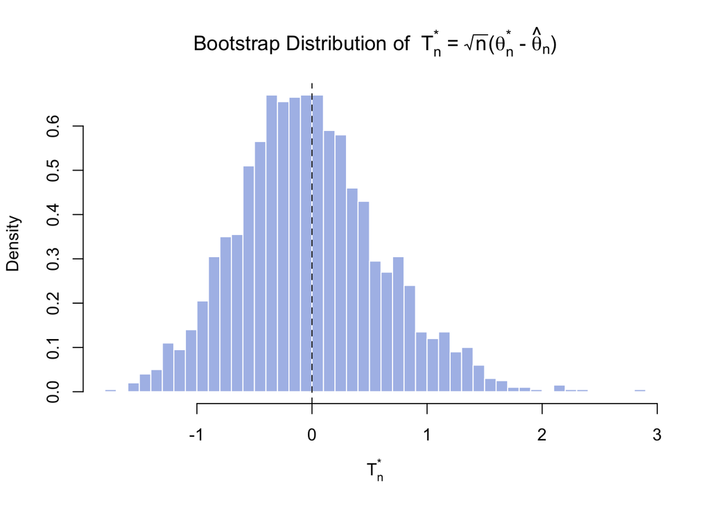

Figure 1: Monte Carlo approximation to the bootstrap sampling distribution $J_n(t,\hat P_n)$, for the sample mean.

```r
hist(T_star, breaks = 40, freq = FALSE,
     col = rgb(0.2, 0.4, 0.8, 0.45), border = "white",
     main = expression(paste("Bootstrap Distribution of  ",
                              T[n]^"*", " = ", sqrt(n), "(", theta[n]^"*", " - ", hat(theta)[n], ")")),
     xlab = expression(T[n]^"*"))
abline(v = 0, lty = 2)
```

**NoteWhy does $J^*_{n,B}$ improve as $B$ grows, but not as an estimator of $J_n(t,P)$?**

Reread **Slide 19**, point 1, carefully: $J_n(t,\hat P_n)$ is itself a fixed (if hard to compute) number, once the data are fixed. $J_{n,B}^*(t,\hat P_n)$ is a Monte Carlo *approximation* of that fixed number — increasing $B$ only reduces simulation noise around $J_n(t,\hat P_n)$, it does **not** bring us closer to $J_n(t,P)$. Try the experiment below to see this for yourself.

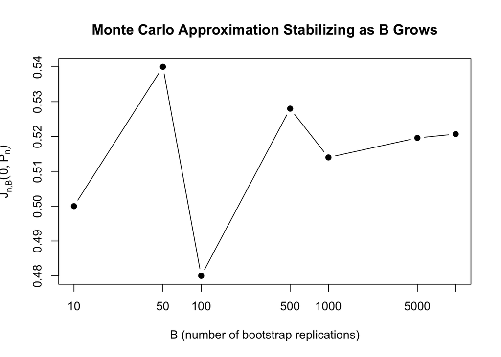

J*_{n,B}(0, P_hat_n) stabilizes as B grows – it is converging to the fixed number J_n(0, P_hat_n), not to J_n(0,P).

```r
B_grid <- c(10, 50, 100, 500, 1000, 5000, 10000)
J_at_0 <- sapply(B_grid, function(Bv) {
  Tv <- replicate(Bv, sqrt(n) * (mean(sample(X, n, replace = TRUE)) - theta_hat))
  mean(Tv <= 0)
})

plot(B_grid, J_at_0, type = "b", pch = 19, log = "x",
     xlab = "B (number of bootstrap replications)",
     ylab = expression(J["n,B"]^"*" * group("(", list(0, hat(P)[n]), ")")),
     main = "Monte Carlo Approximation Stabilizing as B Grows")
```

# 2 Part 2 — A Simplified Parametric Bootstrap

**Slides 21–22** contrast the empirical (nonparametric) bootstrap with the parametric bootstrap: when we are willing to assume a parametric *shape* for $P$, we can replace $\hat P_n$ with a fitted parametric distribution $P_{\hat\eta}$ instead of the empirical CDF, and resample from $P_{\hat\eta}$ directly.

We use the simplest possible scenario: $X_1,\dots,X_n \overset{iid}\sim \text{Exponential}(\lambda)$, and $\theta(P) = \lambda$, estimated by maximum likelihood, $\hat\lambda_n = 1/\bar X_n$.

```r
set.seed(2026, kind = "L'Ecuyer-CMRG")

n        <- 30
lambda0  <- 2                       # true rate
X        <- rexp(n, rate = lambda0)
lambda_hat <- 1 / mean(X)           # MLE of the rate
lambda_hat
```

```
[1] 2.266435
```

Compare the **two** competing bootstrap estimators of $J_n(t,P)$:

- **Nonparametric**: $J_n(t,\hat P_n)$, resampling pairs $X_i^*$ from the empirical distribution (exactly as in Part 1).
- **Parametric**: $J_n(t; \text{Exponential})$, resampling $X_i^{**} \overset{iid}\sim \text{Exponential}(\hat\lambda_n)$ (**Slide 22**), i.e. simulating brand-new data from the *fitted parametric model* rather than reshuffling the observed data.

```r
B <- 2000
T_star_nonpar <- numeric(B)
T_star_par    <- numeric(B)

for (j in 1:B) {

  # Nonparametric bootstrap: resample the n observations
  X_star  <- sample(X, size = n, replace = TRUE)
  lambda_star_j <- 1 / mean(X_star)
  T_star_nonpar[j] <- sqrt(n) * (lambda_star_j - lambda_hat)

  # Parametric bootstrap: simulate from Exponential(lambda_hat)
  X_starstar <- rexp(n, rate = lambda_hat)
  lambda_starstar_j <- 1 / mean(X_starstar)
  T_star_par[j] <- sqrt(n) * (lambda_starstar_j - lambda_hat)
}
```

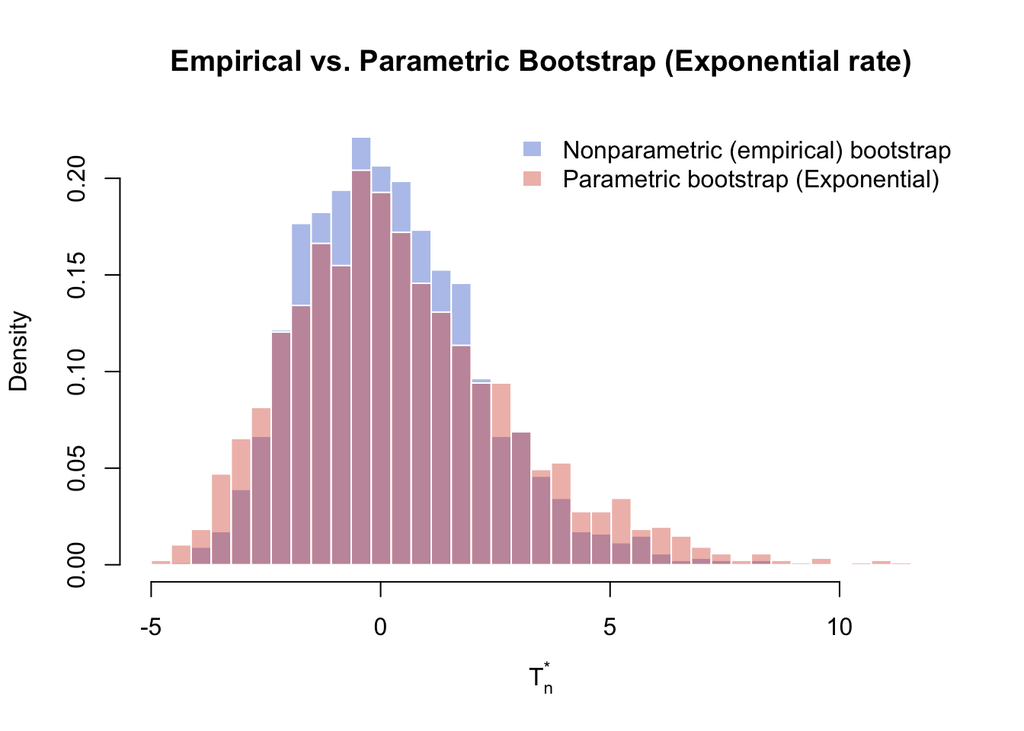

Figure 2: Nonparametric (empirical) vs. parametric bootstrap distributions for the MLE rate of an Exponential(lambda).

```r
xr <- range(c(T_star_nonpar, T_star_par))
br <- seq(floor(xr[1]), ceiling(xr[2]), length.out = 40)

h1 <- hist(T_star_nonpar, breaks = br, plot = FALSE)
h2 <- hist(T_star_par,    breaks = br, plot = FALSE)

plot(h1, col = rgb(0.2, 0.4, 0.8, 0.4), border = "white",
     main = "Empirical vs. Parametric Bootstrap (Exponential rate)",
     xlab = expression(T[n]^"*"), freq = FALSE,
     ylim = range(0, h1$density, h2$density))
plot(h2, col = rgb(0.85, 0.3, 0.2, 0.4), border = "white", freq = FALSE, add = TRUE)
legend("topright", bty = "n",
       fill = c(rgb(0.2, 0.4, 0.8, 0.4), rgb(0.85, 0.3, 0.2, 0.4)),
       border = NA,
       legend = c("Nonparametric (empirical) bootstrap", "Parametric bootstrap (Exponential)"))
```

**TipDiscussion question for class**

The two distributions in the figure above are similar here because the Exponential model is, in fact, correctly specified. *What would happen to the parametric bootstrap distribution if the true $P$ were not Exponential, e.g. a Gamma$(2, \lambda)$ with the same mean?* The empirical bootstrap remains valid (it never assumed a shape for $P$); the parametric bootstrap, run under the (now wrong) Exponential model, would be approximating $J_n(t,P_{\hat\eta})$ for the wrong parametric family entirely. This is the central trade-off between Sections 1 and 2: the parametric bootstrap can be more efficient when the model is correct, at the cost of inconsistency when it is not.

# 3 Part 3 — Measures of Performance (Slide 29)

We now turn to an entire section on **measures of performance**, following **Slides 29–35** essentially line by line. As stated on **Slide 29**, rather than estimating the *entire* sampling distribution $J_n(t,P)$, we may only care about specific features of it:

1. **Mean**: $\mathbb E[\sqrt n \{\hat\theta_n - \theta(P)\}]$.
2. **Bias**: $\text{Bias}_n(P) \equiv \mathbb E[\hat\theta_n - \theta(P)]$.
3. **Variance**: $\mathbb V[\sqrt n \{\hat\theta_n - \theta(P)\}]$.

To make this concrete and to connect back to your own code, we use the **sample variance** as $\hat\theta_n$,
$$\hat\theta_n = \frac{1}{n}\sum_{i=1}^n (X_i - \bar X_n)^2,$$
which is well known to be **biased** in finite samples ($\mathbb E[\hat\theta_n] = \frac{n-1}{n}\sigma^2 \ne \sigma^2$), making it a much more interesting object than the sample mean for this section.

## 3.1 Bootstrapping the Bias (Slides 30–32)

Recall the plug-in logic from **Slide 31**: since $\text{Bias}_n(P) = \mathbb E_P[\hat\theta_n - \theta(P)]$, the bootstrap analogue simply replaces $P$ by $\hat P_n$,
$$\text{Bias}_n(\hat P_n) = \mathbb E_{\hat P_n}[\theta_n^* - \hat\theta_n].$$

```r
set.seed(2026, kind = "L'Ecuyer-CMRG")

n   <- 25
sig2 <- 4
B   <- 3000

X <- rnorm(n, mean = 0, sd = sqrt(sig2))

theta_hat_fun <- function(x) mean((x - mean(x))^2)   # the (biased) sample variance
theta_hat_n   <- theta_hat_fun(X)

# STEP 1-2 (Slide 32): draw B bootstrap samples, compute theta*_{n,j} - theta_hat_n
diffs_star <- numeric(B)
for (j in 1:B) {
  X_star <- sample(X, size = n, replace = TRUE)
  diffs_star[j] <- theta_hat_fun(X_star) - theta_hat_n
}

# STEP 3 (Slide 32): Bias*_{n,B}(P_hat_n) = (1/B) * sum_j { theta*_{n,j} - theta_hat_n }
bias_boot <- mean(diffs_star)

# Known finite-sample bias for this estimator: -sigma^2 / n
bias_true <- -sig2 / n

cat("Bootstrap bias estimate :", round(bias_boot, 4), "\n")
```

```
Bootstrap bias estimate : -0.0992
```

```r
cat("Exact finite-sample bias:", round(bias_true, 4), "\n")
```

```
Exact finite-sample bias: -0.16
```

Notice exactly what we computed: `diffs_star` stores $\theta_{n,j}^* - \hat\theta_n$ for each bootstrap replication, and `bias_boot` is literally the **sample mean of the bootstrap distribution**, recentered at $\hat\theta_n$. This *is* the first moment of $J_n(t,\hat P_n)$ referenced on **Slide 35**, item 1 — nothing more exotic than that.

## 3.2 Bootstrapping the Variance (Slides 33–34)

Likewise, **Slide 33** defines the bootstrap variance estimator as
$$\mathbb E_{\hat P_n}\Big[\,n\,\big(\theta_n^* - \hat\theta_n\big)^2\,\Big],$$
i.e., the **second moment** of the (recentered, rescaled) bootstrap distribution.

```r
# Re-use diffs_star = theta*_{n,j} - theta_hat_n from above
# n * diffs_star^2 corresponds to {T*_{n,j}}^2 with T*_{n,j} = sqrt(n)(theta*_{n,j} - theta_hat_n)

var_boot <- mean(n * diffs_star^2)

# Compare to a "plug-in" / method-of-moments estimate of the asymptotic variance
# of the sample variance: Var = mu4 - sigma^4 (population fourth central moment minus sigma^4)
var_mom <- mean((X - mean(X))^4) - mean((X - mean(X))^2)^2

# True asymptotic variance under normality: 2*sigma^4
var_true <- 2 * sig2^2

cat("Bootstrap variance estimate     :", round(var_boot, 3), "\n")
```

```
Bootstrap variance estimate     : 8.753
```

```r
cat("Method-of-moments estimate      :", round(var_mom, 3), "\n")
```

```
Method-of-moments estimate      : 8.5
```

```r
cat("True asymptotic variance (2s^4) :", round(var_true, 3), "\n")
```

```
True asymptotic variance (2s^4) : 32
```

## 3.3 Connecting Mean, Bias, and Variance to the Moments of $J_n^*(t,\hat P_n)$

The figure below makes the connection from **Slide 35** completely visual: the same bootstrap histogram you have already built carries *both* pieces of information simultaneously: its center (relative to zero) is the bias, and its spread is the variance.

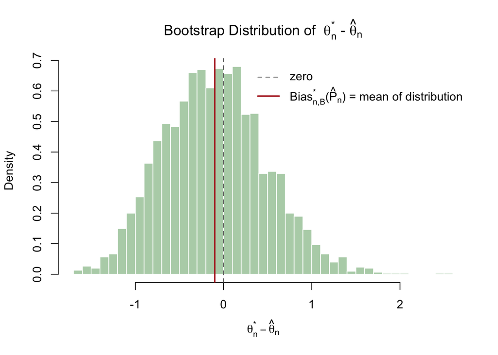

Figure 3: The bootstrap distribution of theta*_n - theta_hat_n: its mean is the bootstrap bias estimate, its second moment (about zero) is the bootstrap variance estimate (after rescaling by n).

```r
hist(diffs_star, breaks = 40, freq = FALSE,
     col = rgb(0.3, 0.6, 0.3, 0.45), border = "white",
     main = expression(paste("Bootstrap Distribution of  ",
                              theta[n]^"*", " - ", hat(theta)[n])),
     xlab = expression(theta[n]^"*" - hat(theta)[n]))
abline(v = 0, lty = 2, col = "grey40")
abline(v = bias_boot, lwd = 2, col = "firebrick")
legend("topright", bty = "n", lty = c(2, 1), lwd = c(1, 2),
       col = c("grey40", "firebrick"),
       legend = c("zero", expression(paste("Bias"["n,B"]^"*", "(", hat(P)[n], ") = mean of distribution"))))
```

# 4 Exercises

**ImportantExercise 1 — Exact Enumeration for $n=3$**

Extend the exact-enumeration code from Part 1 (currently for $n=2$) to $n=3$, using three toy values $a<b<c$. How many bootstrap samples are there now? Tabulate $\theta_n^*$ and its probability for each one, and verify that the implied distribution of $T_n^*$ is symmetric around $0$ whenever $\theta(P)$ is the sample mean. (Hint: `expand.grid()` again, with three arguments.)

**ImportantExercise 2 — How Many Bootstrap Replications Are “Enough”?**

Reproduce the `B`-sensitivity plot from Part 1, but track the **bootstrap variance estimate** of the sample mean (not $J_{n,B}^*(0,\hat P_n)$) as a function of $B \in \{10, 50, 100, 500, 1000, 5000, 10000\}$. At what point does the curve visually stabilize? Repeat with a smaller sample size $n=10$ — does the required $B$ change?

**ImportantExercise 3 — Parametric Bootstrap Under Misspecification**

Modify the Part 2 code: keep simulating the *true* data from a $\text{Gamma}(\text{shape}=2,\text{rate}=\lambda_0)$ distribution (same mean as before, $\mathbb E[X] = 2/\lambda_0$), but leave the **parametric** bootstrap step resampling from $\text{Exponential}(\hat\lambda_n)$ as before (i.e., a deliberately *wrong* parametric model). Compare the parametric and nonparametric bootstrap variance estimates of $\hat\lambda_n = 1/\bar X_n$ to a large-sample Monte Carlo “truth” (simulate many fresh data sets directly and compute the variance of $\hat\lambda_n$ across them). Which bootstrap remains close to the truth?

**ImportantExercise 4 — Bias-Correction**

Using the `bias_boot` estimate from Part 3, construct the **bias-corrected** estimator $\tilde\theta_n = \hat\theta_n - \text{Bias}_{n,B}^*(\hat P_n)$ for the sample variance. Run a small simulation (a few hundred replications of generating fresh data, computing $\hat\theta_n$, bootstrapping the bias, and bias-correcting) to check whether $\tilde\theta_n$ has, on average, smaller bias than $\hat\theta_n$ relative to the true $\sigma^2$. Is there a cost in terms of variance?

# 5 Recap

- The bootstrap distribution is built by literally enumerating (or, for realistic $n$, Monte Carlo approximating) all hypothetical samples from $\hat P_n$, exactly as in **Slides 10–19**.
- The parametric bootstrap changes only *where we resample from* ($P_{\hat\eta}$ instead of $\hat P_n$); the Monte Carlo machinery around it is unchanged (**Slides 21–22**).
- Bias and variance (the “measures of performance” of **Slide 29**) are nothing but the first and second moments of the very same bootstrap distribution we already use to approximate $J_n(t,\hat P_n)$ (**Slides 30–35**). No new simulation is required to obtain them once you have the bootstrap replicates in hand.